# findings

### QTM 151 Final

Dalton Lowery, Parker Carrus, Sanjana Ramen

Please use Outline to navigate Project!

### Our Question

How did the quality of life, measured in terms of political freedom, civil rights, and economic prosperity progress over diffrent the most recently measurable democrate and republican president

```python
# packages
import pandas as pd
import matplotlib.pyplot as plt
import os

# set working directory
os.chdir('C:/Users/dalto/OneDrive/Pictures/Documents/Projects/QTM_151_Final/data')
```

### Change In Political Freedom

Civil Rights Data

import civil rights data

```python
# data
civil_poli_rights = pd.read_csv('./cpr.csv')
civil_poli_rights.head()
```

|  | country | year | countryyear | iso3c | iso3n | cowcode | hrmicode | disap_mean | disap_sd | disap_lo | ... | rel_lo | rel_hi | physint_mean | physint_sd | physint_lo | physint_hi | empower_mean | empower_sd | empower_lo | empower_hi |
| --- | --- | --- | --- | --- | --- | --- | --- | --- | --- | --- | --- | --- | --- | --- | --- | --- | --- | --- | --- | --- | --- |
| 0 | Angola | 2017 | AGO2017 | AGO | 24.0 | 540.0 | 1 | 6.464161 | 0.898106 | 5.314585 | ... | NaN | NaN | 4.401868 | 0.795705 | 3.383366 | 5.420371 | 2.735583 | 0.737381 | 1.791735 | 3.679431 |
| 1 | Angola | 2018 | AGO2018 | AGO | 24.0 | 540.0 | 1 | 7.174069 | 0.491192 | 6.545342 | ... | NaN | NaN | 5.122885 | 0.812793 | 4.082510 | 6.163259 | 4.580472 | 0.701104 | 3.683059 | 5.477886 |
| 2 | Angola | 2019 | AGO2019 | AGO | 24.0 | 540.0 | 1 | 6.357960 | 0.626105 | 5.556545 | ... | NaN | NaN | 4.486554 | 0.790036 | 3.475308 | 5.497800 | 4.226362 | 0.671121 | 3.367327 | 5.085398 |
| 3 | Angola | 2020 | AGO2020 | AGO | 24.0 | 540.0 | 1 | 5.453531 | 0.792786 | 4.438765 | ... | NaN | NaN | 3.438196 | 0.924271 | 2.255129 | 4.621263 | 2.709881 | 0.691141 | 1.825221 | 3.594541 |
| 4 | Angola | 2021 | AGO2021 | AGO | 24.0 | 540.0 | 1 | 4.963902 | 0.588297 | 4.210882 | ... | NaN | NaN | 3.121782 | 0.849364 | 2.034596 | 4.208967 | 2.996323 | 0.736295 | 2.053865 | 3.938781 |

5 rows × 51 columns

I only want to keep the means for each stat, as we are trying to look at the average change in political freedom over time.

```python
columns_to_keep = ['country', 'year'] + [col for col in civil_poli_rights.columns if col.endswith('_mean')]
civil_poli_rights = civil_poli_rights[columns_to_keep]
civil_poli_rights = civil_poli_rights.drop(columns=['rel_mean']) # the data is corrupted for this col and did not load correctly
civil_poli_rights.head()
```

|  | country | year | disap_mean | exkill_mean | arrest_mean | tort_mean | dpex_mean | express_mean | polpart_mean | assem_mean | physint_mean | empower_mean |
| --- | --- | --- | --- | --- | --- | --- | --- | --- | --- | --- | --- | --- |
| 0 | Angola | 2017 | 6.464161 | 5.088942 | 3.789929 | 3.439210 | 10.0 | 3.453185 | 3.086207 | 2.723736 | 4.401868 | 2.735583 |
| 1 | Angola | 2018 | 7.174069 | 5.283046 | 4.850208 | 4.458768 | 10.0 | 4.758242 | 4.858906 | 4.866562 | 5.122885 | 4.580472 |
| 2 | Angola | 2019 | 6.357960 | 5.029688 | 4.970274 | 4.902350 | 10.0 | 4.125774 | 4.342658 | 4.792945 | 4.486554 | 4.226362 |
| 3 | Angola | 2020 | 5.453531 | 3.844958 | 4.245430 | 4.754113 | 10.0 | 3.376480 | 3.242178 | 2.902467 | 3.438196 | 2.709881 |
| 4 | Angola | 2021 | 4.963902 | 4.165898 | 3.885606 | 3.600660 | 10.0 | 3.392950 | 4.049295 | 3.326435 | 3.121782 | 2.996323 |

drop irrelavant cols

```python
civil_poli_rights = civil_poli_rights.drop(columns=['tort_mean', 'disap_mean', 'dpex_mean', 'physint_mean', 'arrest_mean', 'exkill_mean'])
```

take the means for each year to understand the changes overtime

```python
year_means = civil_poli_rights.groupby('year').mean(numeric_only=True)
```

rename cols so they are easy to understand

```python
column_mapping_summary = {
    'arrest_mean': 'Freedom from arbitrary arrest/imprisonment',
    'assem_mean': 'Right to assembly/association',
    'disap_mean': 'Freedom from disappearance',
    'dpex_mean': 'Freedom from death penalty',
    'exkill_mean': 'Freedom from extrajudicial execution',
    'express_mean': 'Right to opinion/expression',
    'polpart_mean': 'Right to participate in government',
    'rel_mean': 'Freedom of religion/belief',
    'tort_mean': 'Freedom from torture',
    'physint_mean': 'Overall physical integrity rights',
    'empower_mean': 'Overall empowerment rights'
}

# Rename the columns in the DataFrame using the summarized names
year_means = year_means.rename(columns=column_mapping_summary)
```

In the first two years of the trump and biden admins, we can see changing level of political freedom for nations in the world, on average. For the biden administration, indicators of political freedom are decreasing over his first two years in office. However this appears to be following an already existing trend and could potentially be influenced by various confounding variables. For the trump admin, levels of poltical freedom are increasing starting with him taking office. We see a signficant jump in right to assembly as well as right participate in goverment. While these are very promising indicators, there could be various confounding vars that would not allow us to see the full treatment effect.

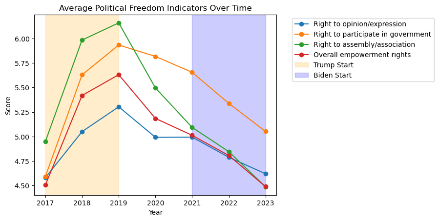

```python
from collections import OrderedDict

ax = year_means.plot(marker='o')
plt.title('Average Political Freedom Indicators Over Time')
plt.xlabel('Year')
plt.ylabel('Score')
plt.legend(title='Indicator', bbox_to_anchor=(1.05, 1), loc='upper left')

# Shade 2017-2018 (Trump start) and 2021-2022 (Biden start)
plt.axvspan(2017, 2019, color='orange', alpha=0.2, label='Trump Start')
plt.axvspan(2021, 2023, color='blue', alpha=0.2, label='Biden Start')

# Only show one label per shaded region in the legend
handles, labels = ax.get_legend_handles_labels()
by_label = OrderedDict(zip(labels, handles))
plt.legend(by_label.values(), by_label.keys(), bbox_to_anchor=(1.05, 1), loc='upper left')
plt.show()
```

People at Risk Data

```python
people_at_risk = pd.read_csv('./people_at_risk.csv')
people_at_risk.head()
```

|  | country | year | countryyear | iso3c | iso3n | cowcode | hrmicode | food_total_atrisk_resp | food_atrisk_count1 | food_atrisk_prop1 | ... | union_atrisk_count27 | union_atrisk_prop27 | union_atrisk_count28 | union_atrisk_prop28 | union_atrisk_count29 | union_atrisk_prop29 | union_atrisk_count30 | union_atrisk_prop30 | union_atrisk_count31 | union_atrisk_prop31 |
| --- | --- | --- | --- | --- | --- | --- | --- | --- | --- | --- | --- | --- | --- | --- | --- | --- | --- | --- | --- | --- | --- |
| 0 | Angola | 2018 | AGO2018 | AGO | 24.0 | 540.0 | 1 | 11 | 3 | 0.272727 | ... | 1.0 | 0.090909 | 2.0 | 0.181818 | 3.0 | 0.272727 | 4.0 | 0.363636 | 1.0 | 0.090909 |
| 1 | Angola | 2019 | AGO2019 | AGO | 24.0 | 540.0 | 1 | 14 | 3 | 0.214286 | ... | NaN | NaN | NaN | NaN | NaN | NaN | NaN | NaN | NaN | NaN |
| 2 | Angola | 2020 | AGO2020 | AGO | 24.0 | 540.0 | 1 | 13 | 3 | 0.230769 | ... | NaN | NaN | NaN | NaN | NaN | NaN | NaN | NaN | NaN | NaN |
| 3 | Angola | 2021 | AGO2021 | AGO | 24.0 | 540.0 | 1 | 12 | 6 | 0.500000 | ... | NaN | NaN | NaN | NaN | NaN | NaN | NaN | NaN | NaN | NaN |
| 4 | Angola | 2022 | AGO2022 | AGO | 24.0 | 540.0 | 1 | 10 | 5 | 0.500000 | ... | NaN | NaN | NaN | NaN | NaN | NaN | NaN | NaN | NaN | NaN |

5 rows × 1358 columns

```python
cols_to_keep = ['country', 'year'] + [col for col in people_at_risk.columns if col.startswith(('arrest', 'assem', 'polpart'))]
people_at_risk = people_at_risk[cols_to_keep]
people_at_risk.head()
```

|  | country | year | arrest_total_atrisk_resp | arrest_atrisk_count1 | arrest_atrisk_prop1 | arrest_atrisk_count2 | arrest_atrisk_prop2 | arrest_atrisk_count3 | arrest_atrisk_prop3 | arrest_atrisk_count4 | ... | polpart_atrisk_count37 | polpart_atrisk_prop37 | polpart_atrisk_count38 | polpart_atrisk_prop38 | polpart_atrisk_count39 | polpart_atrisk_prop39 | polpart_atrisk_count40 | polpart_atrisk_prop40 | polpart_atrisk_count41 | polpart_atrisk_prop41 |
| --- | --- | --- | --- | --- | --- | --- | --- | --- | --- | --- | --- | --- | --- | --- | --- | --- | --- | --- | --- | --- | --- |
| 0 | Angola | 2018 | 12.0 | 0.0 | 0.000000 | 0.0 | 0.000000 | 0.0 | 0.000000 | 0.0 | ... | NaN | NaN | NaN | NaN | NaN | NaN | NaN | NaN | NaN | NaN |
| 1 | Angola | 2019 | 16.0 | 2.0 | 0.125000 | 1.0 | 0.062500 | 1.0 | 0.062500 | 0.0 | ... | NaN | NaN | NaN | NaN | NaN | NaN | NaN | NaN | NaN | NaN |
| 2 | Angola | 2020 | 14.0 | 3.0 | 0.214286 | 1.0 | 0.071429 | 3.0 | 0.214286 | 1.0 | ... | 1.0 | 0.066667 | 0.0 | 0.000000 | 1.0 | 0.066667 | NaN | NaN | NaN | NaN |
| 3 | Angola | 2021 | 12.0 | 3.0 | 0.250000 | 1.0 | 0.083333 | 2.0 | 0.166667 | 1.0 | ... | 1.0 | 0.071429 | 1.0 | 0.071429 | 2.0 | 0.142857 | NaN | NaN | NaN | NaN |
| 4 | Angola | 2022 | 10.0 | 0.0 | 0.000000 | 0.0 | 0.000000 | 1.0 | 0.100000 | 0.0 | ... | 0.0 | 0.000000 | 1.0 | 0.083333 | 0.0 | 0.000000 | 1.0 | 0.083333 | 0.0 | 0.0 |

5 rows × 251 columns

look at the changes in rights for people of certian races, sexual orenitations, and migrants over the final three years of the trump admin, and first three of the biden.

4 = races, 11 = lgbt, 24 = migrants

```python
means_seperated = people_at_risk.groupby('year').mean(numeric_only=True)
prop_cols = [col for col in means_seperated.columns if (
	col.endswith('prop4') or col.endswith('prop11') or col.endswith('prop24')
)]
means_seperated = means_seperated[prop_cols]
```

```python
means_seperated = means_seperated.rename(columns={
    'arrest_atrisk_prop4': 'Arrest (Race/Ethnicity)',
    'arrest_atrisk_prop11': 'Arrest (LGBTQ+)',
    'arrest_atrisk_prop24': 'Arrest (Migrant)',
    'assem_atrisk_prop4': 'Assembly (Race/Ethnicity)',
    'assem_atrisk_prop11': 'Assembly (LGBTQ+)',
    'assem_atrisk_prop24': 'Assembly (Migrant)',
    'polpart_atrisk_prop4': 'Political Participation (Race/Ethnicity)',
    'polpart_atrisk_prop11': 'Political Participation (LGBTQ+)',
    'polpart_atrisk_prop24': 'Political Participation (Migrant)'
})
```

##### Plot Two - Proportion Feeling Unsafe by Marginalized Group

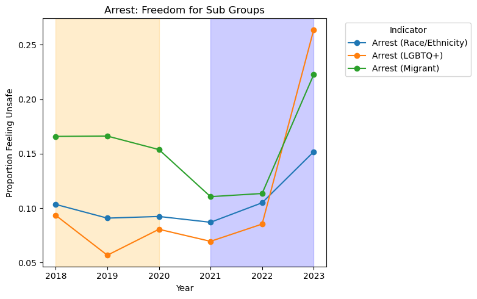

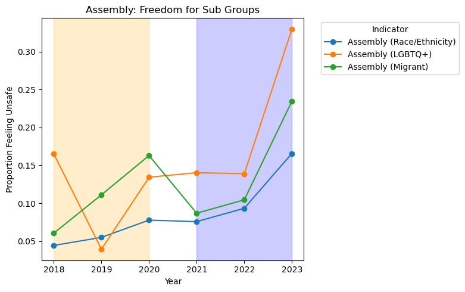

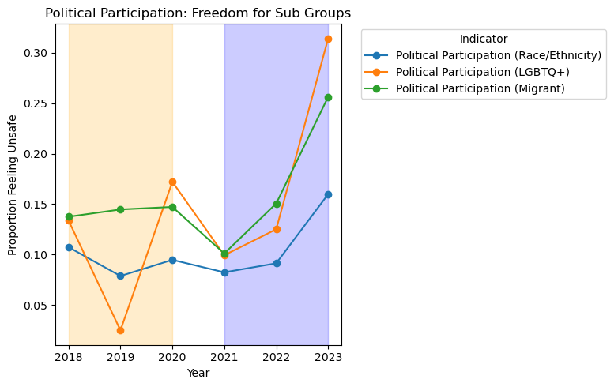

```python
# Arrest
means_seperated[['Arrest (Race/Ethnicity)', 'Arrest (LGBTQ+)', 'Arrest (Migrant)']].plot(marker='o', figsize=(8, 5))
plt.title('Arrest: Freedom for Sub Groups')
plt.ylabel('Proportion Feeling Unsafe')
plt.xlabel('Year')
plt.legend(title='Indicator', bbox_to_anchor=(1.05, 1), loc='upper left')
plt.axvspan(2018, 2020, color='orange', alpha=0.2, label='Trump Start')
plt.axvspan(2021, 2023, color='blue', alpha=0.2, label='Biden Start')
plt.tight_layout()
plt.show()

# Assembly
means_seperated[['Assembly (Race/Ethnicity)', 'Assembly (LGBTQ+)', 'Assembly (Migrant)']].plot(marker='o', figsize=(8, 5))
plt.title('Assembly: Freedom for Sub Groups')
plt.ylabel('Proportion Feeling Unsafe')
plt.xlabel('Year')
plt.legend(title='Indicator', bbox_to_anchor=(1.05, 1), loc='upper left')
plt.axvspan(2018, 2020, color='orange', alpha=0.2, label='Trump Start')
plt.axvspan(2021, 2023, color='blue', alpha=0.2, label='Biden Start')
plt.tight_layout()
plt.show()

# Political Participation
means_seperated[['Political Participation (Race/Ethnicity)', 'Political Participation (LGBTQ+)', 'Political Participation (Migrant)']].plot(marker='o', figsize=(8, 5))
plt.title('Political Participation: Freedom for Sub Groups')
plt.ylabel('Proportion Feeling Unsafe')
plt.xlabel('Year')
plt.legend(title='Indicator', bbox_to_anchor=(1.05, 1), loc='upper left')
plt.axvspan(2018, 2020, color='orange', alpha=0.2, label='Trump Start')
plt.axvspan(2021, 2023, color='blue', alpha=0.2, label='Biden Start')
plt.tight_layout()
plt.show()
```

```python
civil_poli_rights_US = civil_poli_rights[civil_poli_rights['country'] == 'United States']
civil_poli_rights_US = civil_poli_rights_US.rename(columns=column_mapping_summary)
civil_poli_rights_US.head()
```

|  | country | year | Right to opinion/expression | Right to participate in government | Right to assembly/association | Overall empowerment rights |
| --- | --- | --- | --- | --- | --- | --- |
| 111 | United States | 2017 | 5.647172 | 4.143923 | 5.882627 | 5.231153 |
| 112 | United States | 2018 | 5.908282 | 4.916503 | 6.688893 | 5.804997 |
| 113 | United States | 2019 | 5.683665 | 5.126822 | 6.520096 | 5.761158 |
| 114 | United States | 2020 | 5.361212 | 4.716751 | 5.173121 | 4.845300 |
| 115 | United States | 2021 | 6.072245 | 5.158647 | 6.131356 | 5.583263 |